# Schrute Paper

Annual East region summary

May 12, 2022

# 1 Schrute Paper East region annual summary

## 1.1 Industry and Schrute summary

We are Schrute Paper, the foremost purveyor of fine paper and paper accessories. At Schrute Paper, a Scranton, PA-based family-owned business since 1945, we search the world over for paper products from nitrogen-rich soils and bring those products to our customers with a zero-downtime guarantee.

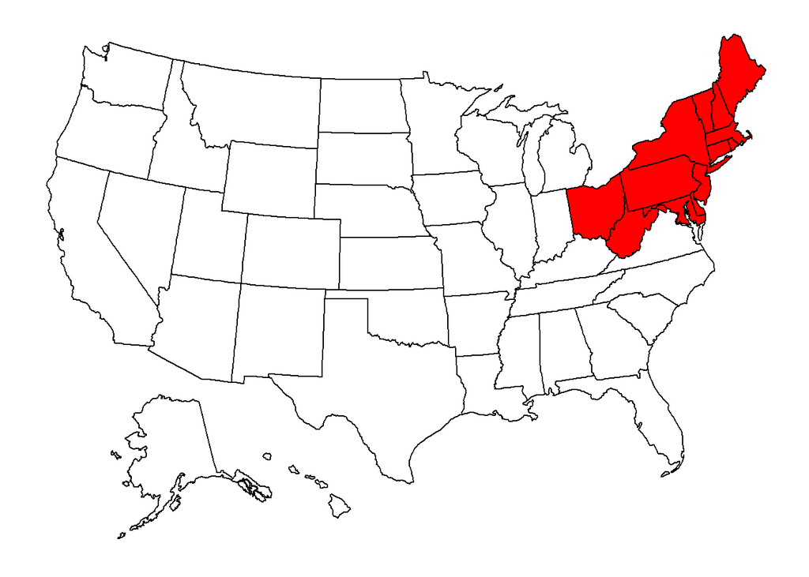

Figure 1.1: Schrute East region map.

## 1.2 Schrute Paper East region financial summary

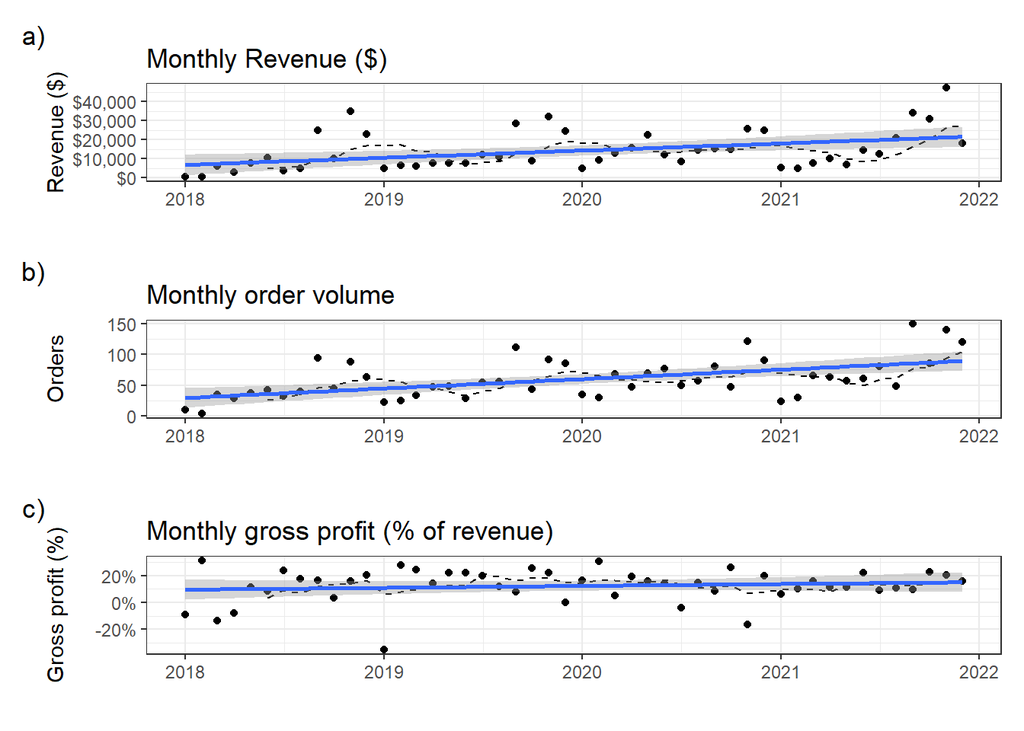

Figure 1.2: Sales trends for Schrute Paper East . Black points are monthly totals. The solid blue trendline is the simple (ordinary least squares) linear regression model of monthly averages. The gray band around the blue trendline shows the 95% confidence interval around model mean predictions. The dashed black line is the six-month moving average of monthly averages.

Schrute Paper East’s business is seasonal. Historically, our 4 month busy season, September through December, accounted for 51% of orders and 59% of revenue (Figure 1.2 a and b).

Schrute Paper East’s business grown over time. Since 2018, monthly mean revenue increased from $6,760 to $21,534. Monthly order volume matched this trend and increased from 29 orders in January 2018 to 89 orders in December 2021. Since 2018, monthly gross profit (as a percentage of revenue) increased from 10% to 15% (Figure 1.2 c).

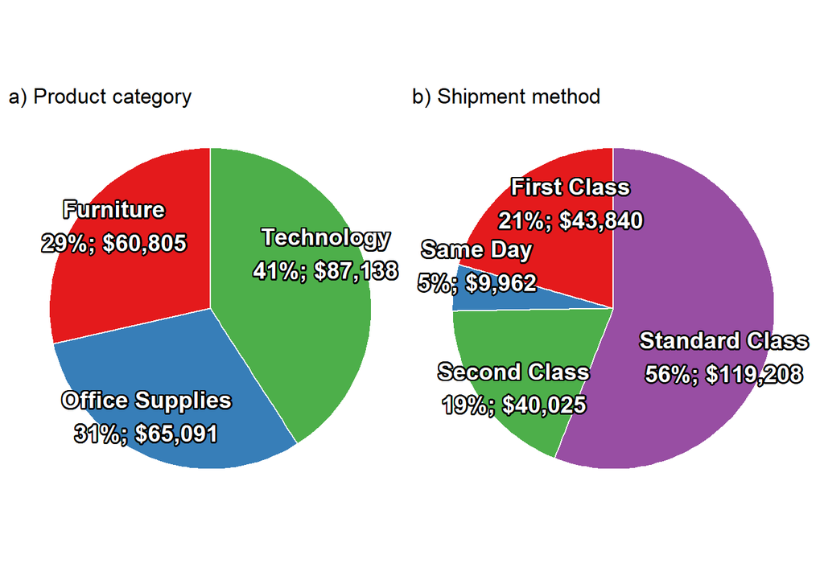

Figure 1.3: Schrute East region 2021 revenue by product category and shipment method.

Schrute Paper East’s 2021 revenue was not evenly distributed among product categories. Technology contributed the most revenue at 41% whereas Furniture contributed the least revenue at 29% (Figure 1.3 a).

Schrute Paper East’s 2021 revenue was not evenly distributed among shipment methods. Orders that shipped via Standard Class contributed the most revenue at 56% whereas orders that moved via Same Day contributed the least revenue at 5% (Figure 1.3 b).

*Table 1. Three largest profit and loss centers for Schrute Paper East in 2021.*

East region profit and cost centers

2021

| Customer | Per order Revenue | Per order Gross profit ($) | Per order Gross profit (%) | Annual totals Revenue | Annual totals Gross profit ($) | Annual totals Gross profit (%) | Annual totals Order Volume |
| --- | --- | --- | --- | --- | --- | --- | --- |
| Three largest cost centers |  |  |  |  |  |  |  |
| Joseph Airdo | $807 | −$168 | −21% | $4,843 | −$1,008 | −21% | 6 |
| Sean Braxton | $242 | −$311 | −129% | $725 | −$934 | −129% | 3 |
| Tom Prescott | $4,416 | −$631 | −14% | $4,416 | −$631 | −14% | 1 |
| Three largest profit centers |  |  |  |  |  |  |  |
| Hunter Lopez | $5,261 | $2,523 | 48% | $10,523 | $5,046 | 48% | 2 |
| Tom Ashbrook | $2,745 | $920 | 34% | $13,723 | $4,599 | 34% | 5 |
| Steven Roelle | $1,753 | $838 | 48% | $3,506 | $1,676 | 48% | 2 |

Schrute Paper East’s 3 largest cost centers produced a loss of $2,573 in 2021 (Table 1). Joseph Airdo accounted for $-1,008 or 39% of this loss. Joseph Airdo’s orders produced an average loss of $-168 and -21%.

Schrute Paper East’s 3 largest profit centers earned the region a profit of $11,321 in 2021 (Table 1). Hunter Lopez accounted for $5,046 or 45% of this profit. Hunter Lopez’s orders produced an average profit of $2,523 and 48%.